# Numerical experiment investigating the influence of drag on trajectory patterns of floating macroalgae

R Coppin[^1], C Rautenbach[^2], AJ Smit[^3]

Abstract

**Abstract**: Ocean currents act as an important dispersal mechanism of material on the ocean surface, both natural and anthropogenic. Macroalgae are one of the most important natural dispersal vectors, and are regarded as the tumble-weed of the ocean. Despite many studies that exist on the topic, the relative role of wind and surface currents in macroalgae trajectory is still unknown. Past studies focus on kelp-rafts, which can vary greatly in size, making it difficult to form a concensus as to the relative role of wind versus surface currents. In addition, past studies have not considered surface-area in relation to drag characterisics of floating macroalgae which have been shown to play a role in the trajectory and accumulation of other flotsam. Advances in Lagrangian trajectory modeling have been exponential in recent years, and allow the use of numerical experiments to investigate trajectories of flotsam in the ocean. This study aimed to shed light on the relative role of wind versus surface currents, and the role of drag in macrolagal trajectory and accumulation. We did not investigate kelp-raft behaviour but instead focused on solitary kelp individuals. This was achieved by comparing simulations of virtual kelp ‘particles’ which incorporate drag with that of purely Lagrangian particles. The results showed that the virtual kelp particles do follow the ocean currents in general, but that the inclusion of drag into the scenarios causes accumulation in eddies within the study domain. The results also point to the importance of sub-mesoscale features, such as eddies, as important surface accumulation zones for solitary floating macroalage.

# Introduction

There is a range of objects — both natural and anthropogenic — floating in the ocean of which macroalgae are regarded as one of the most important passive dispersal mechanisms of marine taxa. Floating kelp acts as a passive dispersal mechanism for a range of marine taxa and is sometimes referred to as the ‘tumble-weed’ of the ocean (Edgar, 1987; Norton, 1992; Bushing, 1994; Helmuth et al., 1994; Holmquist, 1994; Smith, 2002; McCormick et al., 2008). Kelp also function as input of allochthonous materials to near and distant ecosystems and in this manner support the ecological function in a range of adjacent habitats (Bustamante et al., 1995; Colombini et al., 2003; Vanderklift and Wernberg, 2008; Krumhansl and Scheibling, 2012; Filbee-Dexter et al., 2018; Zuercher and Galloway, 2019; Cartraud et al., 2021).

Some macroalgal species are negatively buoyant and sink to the seafloor when detached from the substrate, while other species have air-filled pneumatocysts or stipes which allow the plants to reach the surface where light is more abundant. In turn, the positively buoyant pneumatocysts cause plants to float to the surface when dislodged from the substratum. The structure and number of pneumatocysts varies between species. For example species belonging to the genera *Macrocystis*, *Sargassum*, *Ascophyllum*, and *Fucus* have thalli with many small pneumatocysts, while other kelp species such as *Nereocystis luetkeana*, *Pelagophycus porra*, *Ecklonia radiata*, *Ecklonia maxima* have a single, large pneumatocysts (Dayton, 1985; Smith, 2002; Thiel and Gutow, 2005; Graiff et al., 2016; Batista et al., 2018). In some cases the stipe itself may be air-filled, such as with *E. maxima* and *E. radiata*. Although there have been reports of floating Chlorophyta species and some Rhodophyta species, Phaeophyceae species are the most reported forms of floating algae. This is most likely because the green and red species reported floating are not actually positively buoyant, but instead are kept at the surface by gas trapped in-between or in the thalli (Dromgoole, 1982; Bäck et al., 2000). The giant kelp *Macrocystis pyrifera* (Helmuth et al., 1994; Kingsford, 1995; Hobday, 2000; Macaya et al., 2005; Graiff et al., 2016; Batista et al., 2018), the bull kelp *Durvillaea antarctica* (Smith, 2002; Collins et al., 2010; Wichmann et al., 2012; Tala et al., 2013, 2017; Saunders, 2014; Batista et al., 2018), and pelagic *Sargassum* species (Brooks et al., 2018, 2019; Putman et al., 2018, 2020; Wang et al., 2019) have been the focus of much of the research regarding spatial and temporal dispersal patterns, the ecological role of rafting, marine connectivity and raft-time.

Past research points to macroalgae trajectory being largely determined by prevailing wind conditions and surface currents (Hobday, 2000; Thiel and Gutow, 2005; Fraser et al., 2011; Rothäusler et al., 2011, 2011). Although ocean currents are regarded as the primary influence, the relative importance of wind versus surface current is still unknown although the role of wind has been recognised as important in several studies. For example, a study by Harrold and Lisin (1989) investigated the seasonal trajectories of radio-transmitter tagged *M. pyrifera* in nearshore Monterrey Bay. The results showed that kelp rafts, with little surface area, exposed to the wind were largely driven by a combination of wind and surface currents; however the relative importance of wind and was not clear. In addition, the trajectories of tagged kelp were more consistent with the formation of eddies during winter. Previous studies have also identified wind as an important mechanism of dispersal in wind dominated ocean systems. For example, in the sub-Antarctic latitudes the West Wind Drift causes continuous unidirectional surface flow and is regarded as an important potential mechanism for dispersal of floating bull kelp *Durvillaea antarctica*. Other studies have used genetic approaches to determine macroalgae raft trajectory characteristics by inferring source location from genetically similar populations (Nikula et al., 2013). For example, a study by Fraser et al. (2011) on the rafting capabilities of *D. antarctica* used a combination of population genetics and relative age estimate of goosebarnacles attached to the raft. The presence of goosebarnacles suggests a long rafting, time as these species have a slow growth rate. Genetic analyses showed these species are able to raft up to $\sim$ 390 km from their local origin. The authors suggested that wind and water-movement were the primary influences of trajectory; however, this was only inferred from the genetic results and local climatology data (Fraser et al., 2011). Past research has shown that buoyancy and drag also play a role in determining the trajectory and rate of transport for surface floating material (Furnans et al., 2008; Beron-Vera et al., 2016; Trinanes et al., 2016; D’Asaro et al., 2018; Gates et al., 2018; Onink et al., 2019; Shen et al., 2019). The ‘sail’ area of an object floating at sea is the surface area exposed to the wind which results in air form drag, while the area of the object below the surface of the water is exposed to surface currents which result in hydrodynamic-form drag (Breivik et al., 2011; Griffin et al., 2017). In addition, past research conducted within the maritime industry has shown that the size and shape of a vessel determine the relative importance of waves or wind as drivers of trajectory, as well as orientation of the object. If the length of the object is longer than the significant wave height then waves will be the primary driver of trajectory while the opposite is true for smaller objects where the effect of waves is regarded as negligible (Breivik et al., 2011; Griffin et al., 2017). Drag is ultimately determined by the size and shape of the object which are properties that vary considerably with macroalgae species.

To accurately determine the trajectory of marine macroalgae, water and wind drag need to be taken into account. Past research by Allen and Plourde (1999) and Breivik et al. (2011) have provided estimates of drag for various objects based on experimental work, which consisted of both direct and indirect methods of the Leeway model. However, this work does not consider biological material such as macroalgae. Although drag estimates do exist, these have been applied for macroalgae not detached from the substratum and are regarded as fixed-point estimates. Although various approaches have been used in the past to investigate floating macroalgal trajectories, very few studies have employed the use of Langrangian trajectory modeling. Furthermore, none of the existing studies using this modeling approach have considered macroalgal morphology cross-sectional area (*i.e.* shape) as an aspect of drag and ultimately trajectory. Studies by Brooks et al. (2019), Putman et al. (2018), and Putman et al. (2020) used Lagrangian approaches to investigate the effects of inertia, raft-size, and windage on macroalgae trajectory. Brooks et al. (2019) used a custom growth model to estimate changes in biomass and ultimately radial size, while a customised Hybrid Coordinate Ocean Model (HYCOM) for the trajectory simulations was used. The results showed that the trajectory of pelagic *Sargussum* was significantly influenced by inertia and the radial size of the rafts. Other work by Putman et al. (2020) investigated the effect of including windage in macroalgae trajectory simulations. The authors showed that including *ad hoc* windage factors greatly improved accuracy regarding entrainment or expulsion from eddies when compared to tracked *Sargassum* mats in the ocean. Langrangian trajectory modeling is clearly; useful tool, however, the various models available often assume the object to be a spherical particle, which is obviously not the case for both biological and anthropogenic forms of marine debris in nature. The radial size included by Brooks et al. (2019) is an improvement, however this approach does not consider the complex morphology on an individual level into account.

Past studies have focused on kelp-rafts, not solitary floating kelp, and therefore are not able to investigate the role of eddies and vortices in the accumulation of individual kelp plants at the surface. Gyres, eddies, and converging surface currents have been identified as important in the accumulation and dispersal of plastics and other marine debris (Brach et al., 2018; D’Asaro et al., 2018; Onink et al., 2019). Past studies investigating the dispersal of marine debris have also included the possible effects of inertia in accumulation of ocean drifter instruments in mesoscale features. For example, a study by Beron-Vera et al. (2016) used a modeling approach to investigated the role of Eckman transport and inertia to explain the observed behavior of undrogued drifters in the ocean gyres. Undrogued drifter trajectory is affected by wind unlike the drogue counter parts which makes the effects of wind negligible. The results showed that the combined effect inertia, not Eckman transport, played a significant role in the observed drifter behavior (Beron-Vera et al., 2016). The authors also noted that the presence of other flotsam along with the undrogued drifters in ocean gyres also suggests that aspects inertia also play a role in accumulation of other marine debris (Beron-Vera et al., 2016). The approach by Beron-Vera et al. (2016) has also been improved upon by Beron-Vera et al. (2019) but also shows the significant role of inertia in flotsam trajectory and accumulation.

In this study, a numerical approach is used to shed light on the role of hydrodynamic and direct wind drag on macroalgal drift trajectory using Lagrangian based trajectory simulations. We aim to shed light on the ‘behaviour’ of surface drifting macroalgae from a coastal environment into the open ocean, which will inform future characterisation studies. We will achieve this by comparing the trajectory outputs of virtual passive particles (no drag characteristics added) with kelp particles (drag characteristics added) of varying degrees of hydrodynamic and wind drag exposure. The different degrees of wave and wind exposure are meant to reflect the different buoyancy characteristics, as well as identify the role of magnitude of the drag components on overall trajectory. The modeling of single kelp offers the opportunity to study the role of eddies and vortices in accumulation points on the surface.

# Methods

## Study site

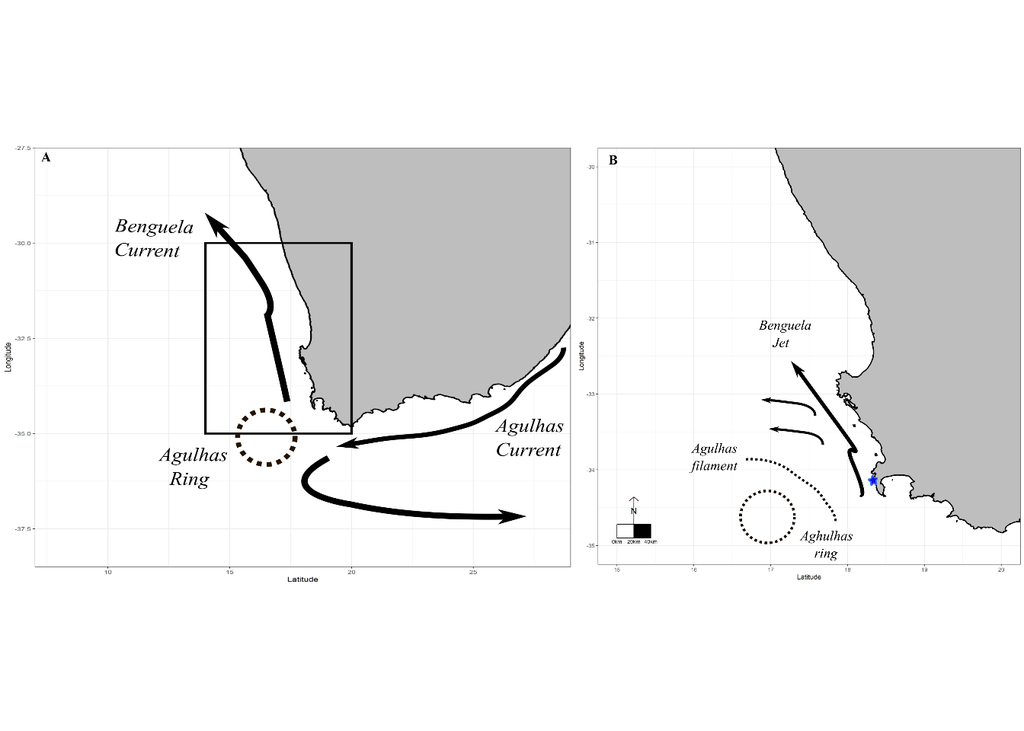

Figure 1: Map of the study domain and the main features pertaining to transport in the region. In panel A, the map of the entire South African coastline and the main currents is presented. The resulting eddies and filaments from the Agulhas retroflection are indicated, and the position of the study area is drawn in as a black rectangle. Detail of the study area is in panel B. Here the splitting of the Benguela Jet, eddie features, and the general flow of the study domain are presented. The release site of simulated kelp ‘particles’ is represented by a blue star.

The study domain falls within the southern Benguela upwelling ecosystem, which is a region of high mesoscale variability and activity in the form of eddies, filaments and vortices generated from the Agulhas retroflection (Veitch and Penven, 2017; Veitch et al., 2018) they generally flow northward along the coastline and begin to move offshore near Cape Columbine. The Benguela Jet is a coastal flowing current and is driven by a complex interaction of eddies, upwelling, Eckman transport and geostrophic currents (Stramma and Peterson, 1989; Hutchings et al., 2009; Veitch and Penven, 2017; Veitch et al., 2018). The stability of the jet varies seasonally with more stable flows in winter; and in January, the jet begins to split between Cape Point and Cape Columbine (Blanke et al., 2002, 2005; Veitch et al., 2018) which results in a weak narrow inshore branch that flows along the shelf edge and a strong flowing north-westwards offshore branch. The area is also characterized by high upwelling activity driven by strong westerly winds (Hutchings et al., 2009). These winds are most intense during summer (December-March) which favors upwelling conditions in the region, and also act to reinforce the flow of the Benguela Jet which occurs due to cold upwelling waters contributing to the across-shore density gradient (Ragoasha et al., 2019). In winter the wind direction is reversed which decreases upwelling favorable conditions, but the core of the Benguela jet is maintained by the intrusion of warm Agulhas waters into the Benguela region over the shelf edge (Hutchings et al., 2009; Veitch et al., 2018; Ragoasha et al., 2019).

## Particle tracking model

The model is based on parameterizations that have been used for previous studies investigating iceberg, capsized marine vessels and microplastics. It should be noted that most of the previous studies regarding macroalgae trajectory have investigated rafts and not solitary floating individuals. A kelp raft will vary in size and can range from a few meters across to large dense mats the size of a rugby field. Some authors suggest that most macroalgae become entangled through ocean currents and not through the hydrodynamic forces that dislodge them. Large kelp rafts are not a feature around the coast of the Cape Peninsula; rather, solitary kelp are (pers. obs). Therefore, the trajectory of only solitary *E. maxima* individuals will be considered. We performed numerical calculations of particle trajectory with a Lagrangian method (Delandmeter and Van Sebille, 2019), and be described by the equation

$$X(t+\Delta t) = X(t) + \int_{t}^{t+\Delta t} v(x, \tau)d \tau + \Delta X_b(t)$$
where $X$ is the three-dimensional position of a particle, $v(x,t)$ is the three-dimensional velocity field at the location in the ocean model at particle point in time, $t$ is time $X_b(t)$ is a change in position due to ‘behavior’ of the particle at a particular point in time. In order to investigate the effects of drag components of trajectory of floating macroalgae, this study incorporated drag as the custom behavior.

This study simulated two scenarios; one where the plant is fully submerged and only exposed to hydrodynamic drag; and the other where parts of the plants are partially exposed resulting in a combination of hydrodynamic and air form drag. Drag based on shape-based coefficients were used in the calculations for determining the overall kelp velocity vectors. A momentum energy equation was used to calculate the drag forces for the relevant simulation. This approach has been employed in modeling iceberg drift trajectory (Lichey and Hellmer, 2001; Eik, 2009; Andersson et al., 2017) and was adapted to suit this study. The energy momentum equation used to calculate the drag force exerted on the virtual kelp particle was,
$$m({d_u/d_t})=F_d + F_a + F_f$$
where $m$ is kelp mass, $d_u$ the virtual kelp particle velocity, $F_d$ the hydrodynamic drag, $F_a$ is the wind drag, $F_f$ the surface-current flow, and $d_t$ is the time step. The assumption made was that the mass of the kelp did not change for each virtual kelp particle over the course of the simulations. Hydrodynamic drag, wind drag, and surface current-flow are two-dimensional vector quantities and were calculated for each time step for each simulation.

## Model inputs

### Ocean and wind model

Both passive and kelp particles were simulated around the South African coastline within hindcast outputs from the Copernicus Marine Environment Monitoring Service (Copernicus, http://marine.copernicus.com). The Copernicus model is based on the modelling framework known as Nucleus for European Modelling of the ocean. The Copernicus outputs used in this study contain 3D daily current information from the top layer to the bottom (Global Analysis Forecast PHY_001_024). The model has a spatial resolution of 0.08$^\circ$ and is interpolated on an Arakawa C native grid. In order to incorporate the effects of direct wind drag within the simulations, the Copernicus Marine Environment Monitoring Service global wind product was used (Global Ocean Wind L4_NRT_012_004). The outputs from the model are composed of 6-hourly averaged fields of surface 10 m wind velocity vectors with a spatial resolution of 0.25$^\circ$. Averaged ocean current and wind data are stored as meridional and zonal velocity vectors.

### Hydrodynamic and wind drag

The drag coefficient for a spherical particle was used in the calculation of hydrodynamic drag as the trajectory model assumes the particles are spherical. The drag equation used was: $F_d = 0.5 \rho A_c C_d U^2$, where $\rho$ is the density of seawater or air, $A_c$ is the cross-sectional area exposed to hydrodynamic or wind drag, $C_d$ is the drag coefficient for a spherical particle and $U$ is the surface velocity vector of the flow-/wind- field. Hydrodynamic and wind drag components were calculated separately for both the meridional and zonal velocity vectors, as per Furnans et al. (2008). Since drag force is dependent on the velocity vectors which vary with time, the meridional and zonal velocities were interpolated and used in the drag force calculation for each time-step. The same approach was used for the wind drag force. The equation that was used to calculate hydrodynamic drag, was also used to calculate wind drag.

### Cross-sectional area

To incorporate hydrodynamic and wind drag, the cross-sectional area of the kelp was calculated first. Known geometric shapes reflecting the relevant plant sections were used to estimate the surface area for various parts of the plant. For details refer to figure 2. The dimensional data needed were estimated in cases where data was not available for that particular morphological characteristic. The bulb/pneumatocyst is a highly variable morphological characteristic and in some cases can appear absent; the same is true for the holdfast. Therefore, a standard cross-sectional area was used for both the bulb and holdfast, for all simulations.

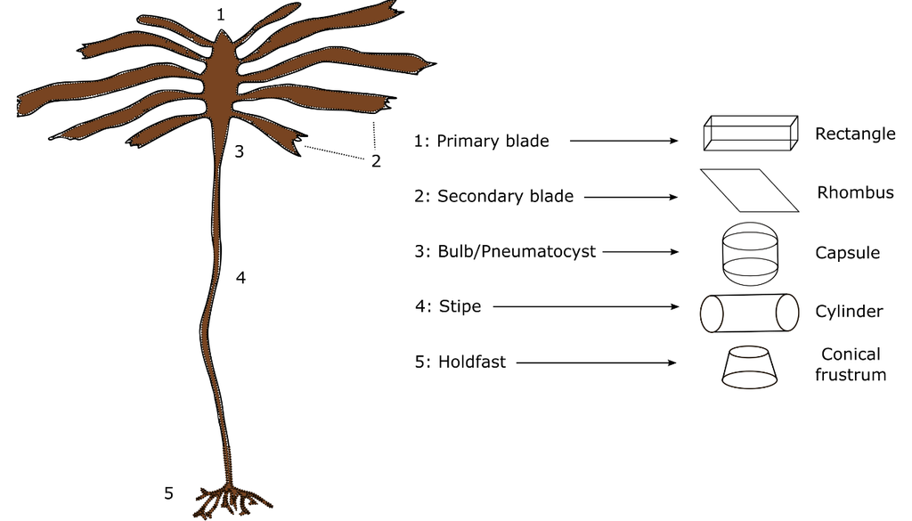

Figure 2: Diagram of the *E. maxima* morphological characteristics considered in this study, along with the associated geometric shapes used to calculate the overall surface area of each morphological characteristic.

## Analysis

# Results

## Trajectory comparison

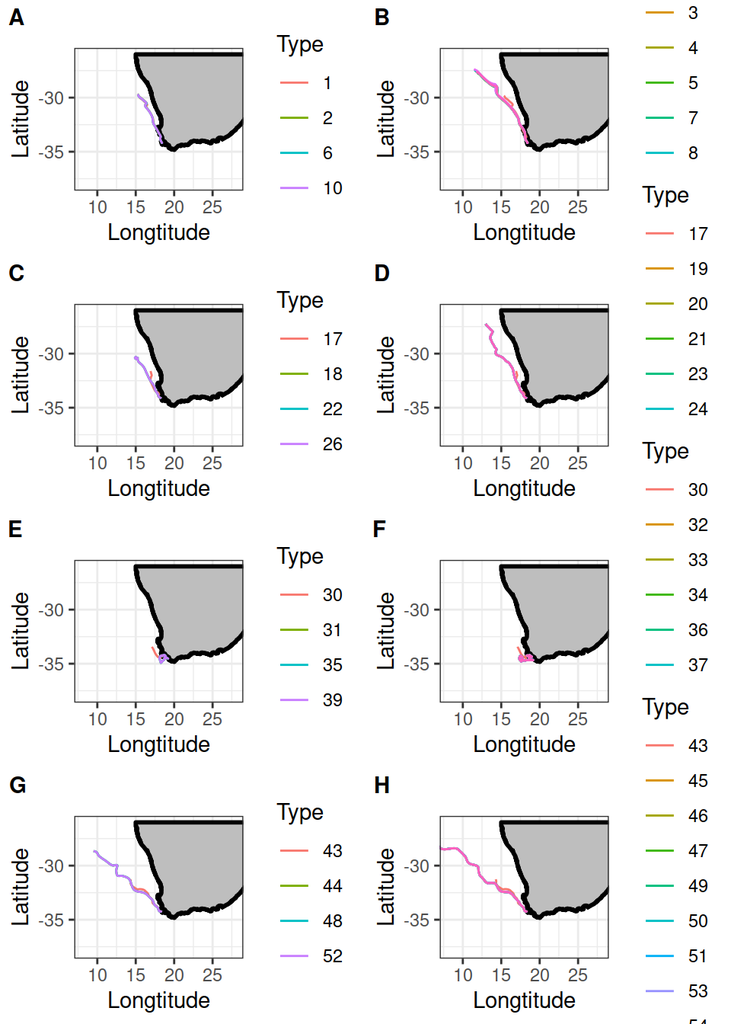

## Comparison of density distributions

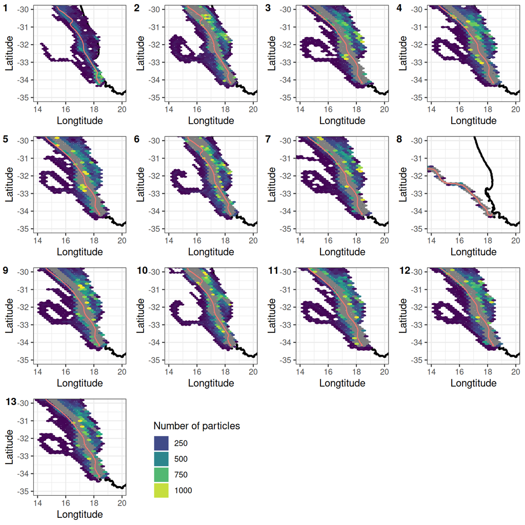

Figure 3: Comparison of density plots at the end run time for scenarios 1 - 13, for January 2018 (summer). The plots are regular hexagons within the density of particles were calculated. The mean trajectories for each scenario are also plotted for comparison. The reader is referred to tables 1 and 2 for details pertaining to each scenario.

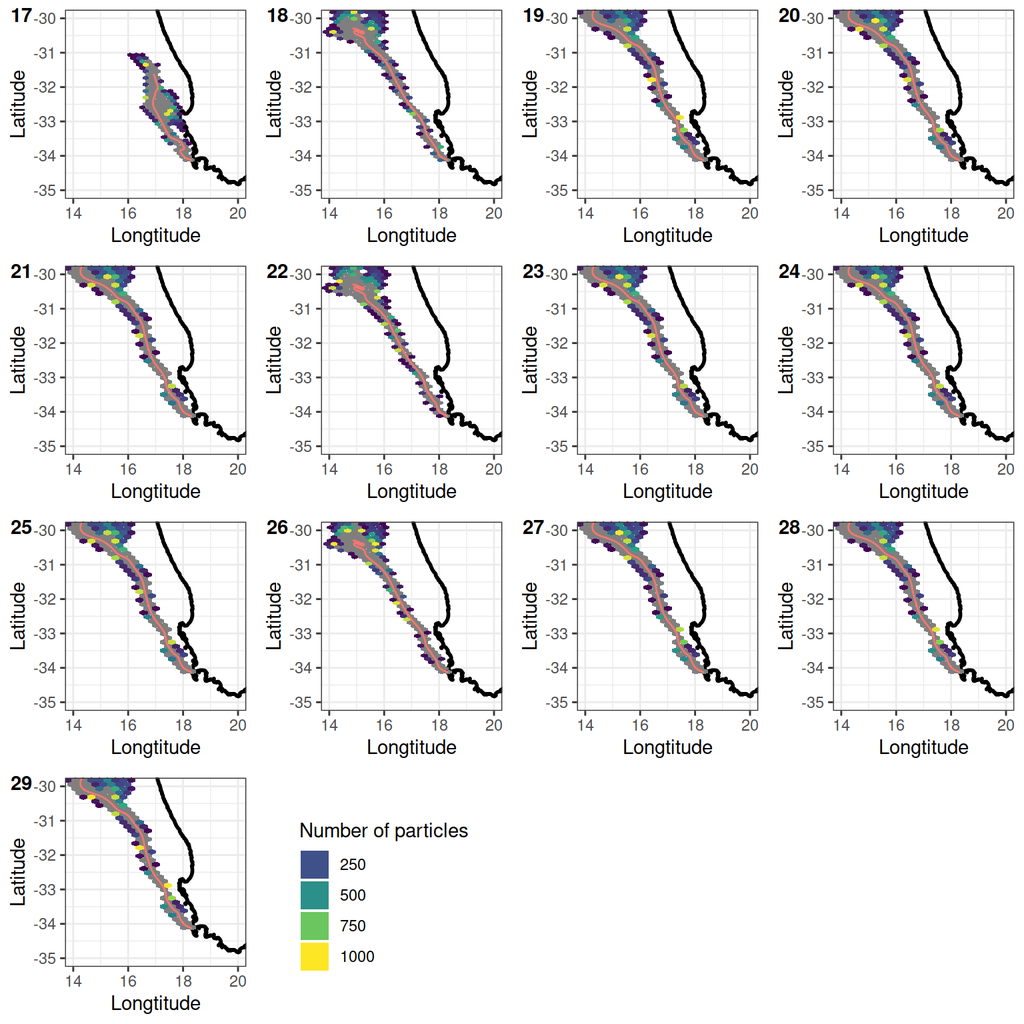

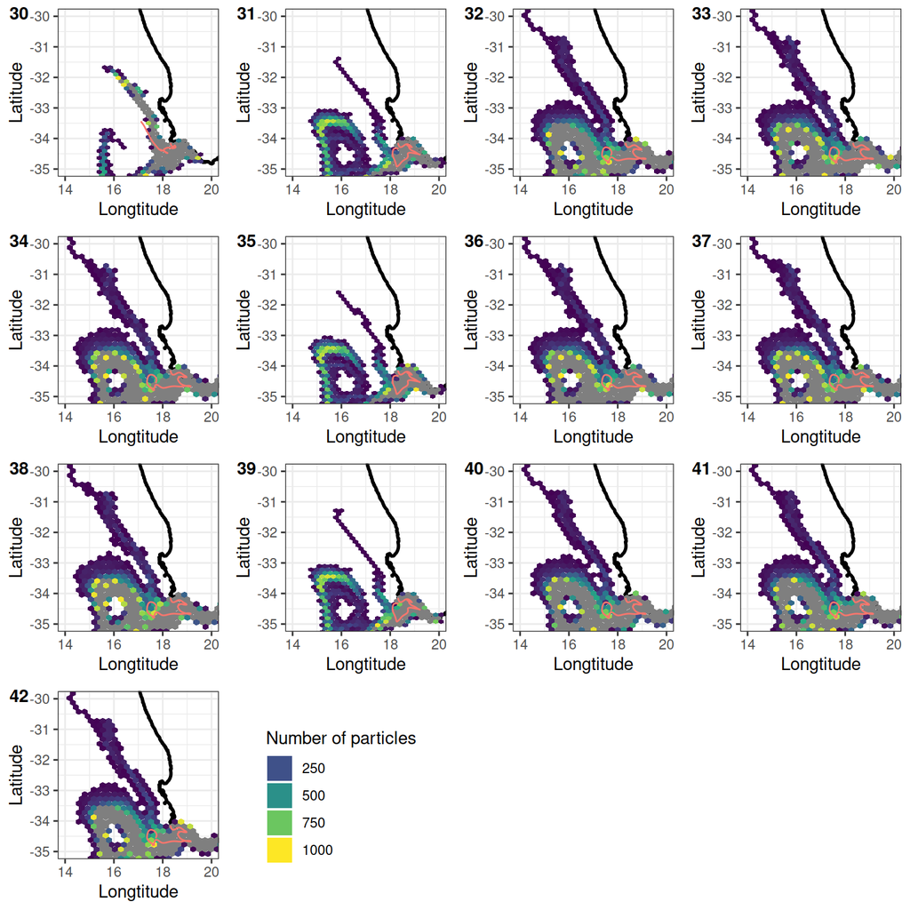

Figure 5: Comparison of density plots at the end run time for scenarios 30 - 42, for July 2018 (winter). The plots are regular hexagons within the density of particles were calculated. The mean trajectories for each scenario are also plotted for comparison. The reader is referred to tables 1 and 2 for details pertaining to each scenario.

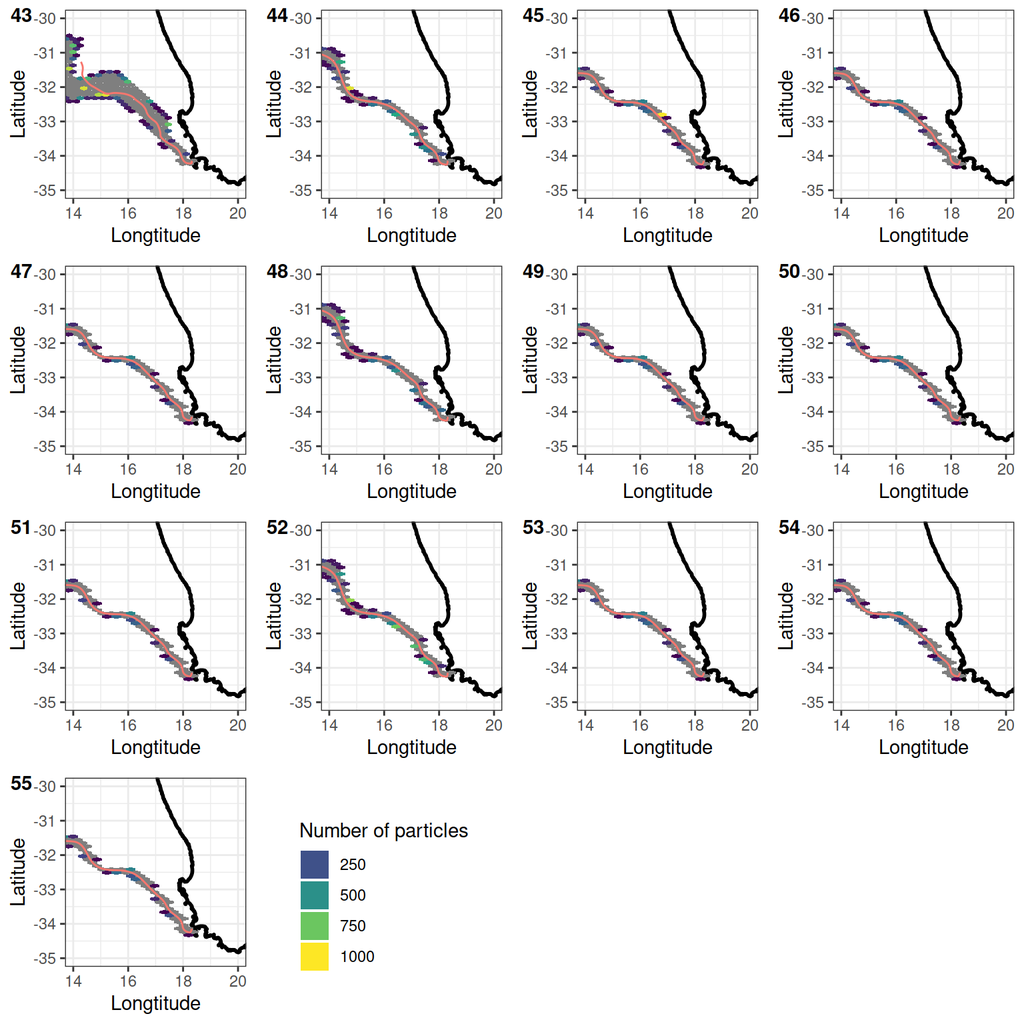

Figure 6: Comparison of density plots at the end run time for scenarios 43 - 55, for October 2018 (spring). The plots are regular hexagons within the density of particles were calculated. The mean trajectories for each scenario are also plotted for comparison. The reader is referred to tables 1 and 2 for details pertaining to each scenario.

## Comparison of distances

```
## $`1`
```

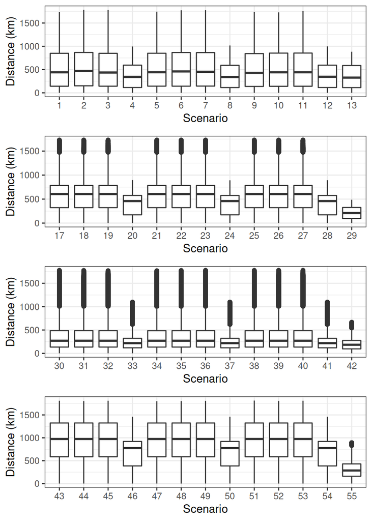

```
##
## $`2`
```

[output not shown]

## Accumulation

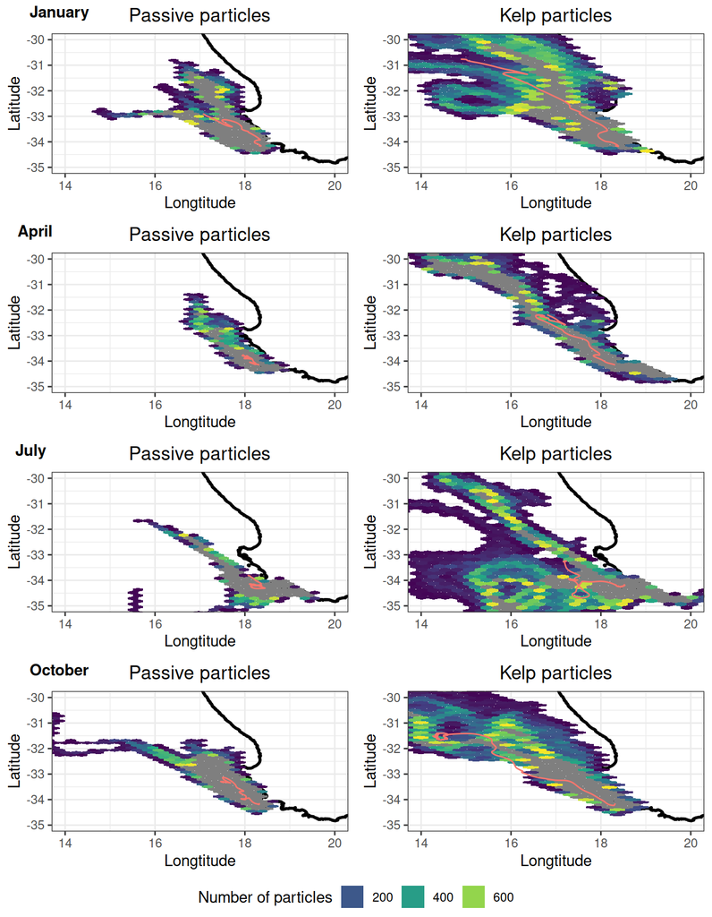

Figure 8: Comparison of density between passive and kelp accumulation scenarios.

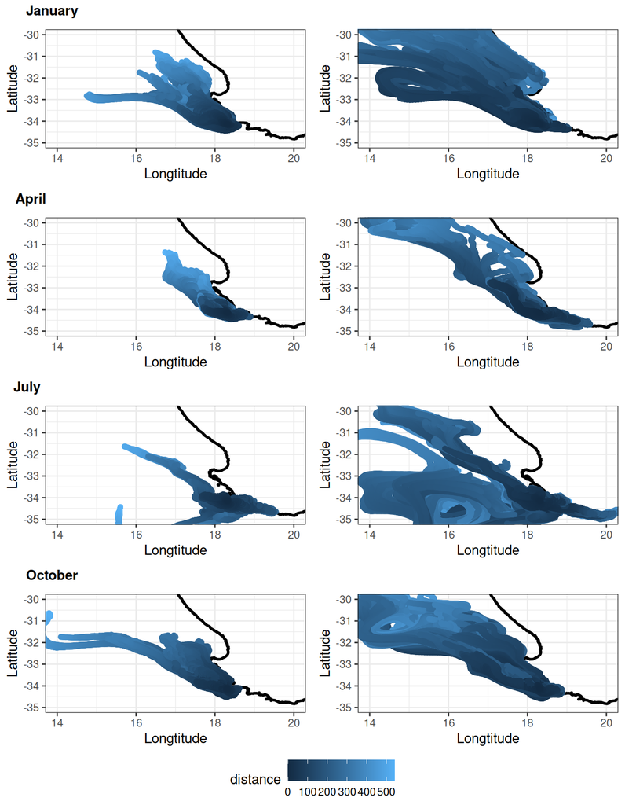

# Discussion

The treatment of drifting macroalgae as purely Lagrangian will not be able to accurately determine patterns of passive dispersal, such as entrainment in eddies or vortices (Fossette et al., 2012; Miron et al., 2020). Although past research has shown the inclusion of inertia and windage greatly increase observed macroalgae trajectory and entrainment characteristics (Brooks et al., 2018, 2019; Putman et al., 2018, 2020), past research has focused on large macroalgal-rafts which can vary greatly in size and surface area. None of the past research has taken advantage of the advancement in numerical ocean models and Lagrangian trajectory modeling to investigate how aspects of drag (hydrodynamic and wind) affect the trajectory patterns of solitary drifting macroalgae. This study compared particles trajectories with simulations that included no forms of drag with simulations that included various forms of both hydrodynamic and wind drag. The mean virtual kelp trajectory deviated from the mean passive trajectory when including varying levels of hydrodynamic and wind drag scenarios. The results from this study show the inclusion of hydrodynamic and wind drag results in observable entrainment patterns, and broadens our understanding of how surface area plays a role in solitary drifting macroalgae trajectory, in this case that of *E. maxima*.

Past research has inferred from direct and indirect techniques that drifting macroalgae tend to follow the prevailing surface currents (Hobday, 2000; Thiel and Gutow, 2005; Fraser et al., 2011; Rothäusler et al., 2011, 2011). The results from this numerical experiment confirm that drifting macroalgae do follow the surface current in the study region when considering only hydrodynamic drag. In addition, not only are the trajectories similar but so are the end points at the end of simulation. However, when *ad hoc* wind drag (windage) is considered in combination with hydrodynamic drag the end locations differ greatly when compared to purely Lagrangian particle trajectories. The inclusion of wind drag causes the kelp particles to flow further away from the coast and with a greater distance travelled from the release location. The difference in trajectory and distance covered can be attributed to the inclusion of wind drag. Wind drag adds to the effects of hydrodynamic drag when the wind direction and current direction are opposite to each other. However, when the wind direction is in the same or similar direction to that of the current, momentum energy from the wind is transferred to the object (Hackett et al., 2006; Putman et al., 2020). This causes the kelp particles to travel further as well as exposed to different time varying flows. Past studies have shown this when including windage as a function of inertia (Putman et al., 2018, 2020; Brooks et al., 2019). A study by Putman et al. (2020) used *ad hoc* windage factors that was based on the surface current velocity to assess the approach for improving transport predictions of pelagic *Sargassum sp*. The results showed that including ad-hoc windage factors improved virtual trajectories compared to tracked *Sargassum sp* mats which was partly due to the inclusion of momentum energy transfer from wind. This is also reflected in the analysis comparing distances travelled by all the particles in each simulation. The particles in the simulations that included wind drag traveled significantly greater distances compared to the passive or hydrodynamic only drag. Similar patterns are seen in the additional simulations run for April (autumn), July (winter), and October (spring); however even kelp particles with only hydrodynamic drag flow further compared to passive particles in these times of the year. This may be a result of the kelp particles exposed to different time-varying flows, which results in the kelp particles following a different surface current vector compared to passive particles. This also results in different end-points and therefore these results further confirm that drag is an important factor to account for when investigating macroalgal drift patterns.

The addition of drag forces causes the kelp particles to cluster together along the mean trajectory compared to that of the passive particles which are more evenly dispersed. This is most likely due to the shared drag characteristics among the kelp particles which included the plants weight and surface area into the calculation. Other studies investigating flotsam trajectory characteristics have found similar results (Breivik et al., 2011; Miron et al., 2020; Olascoaga et al., 2020). A study by Miron et al. (2020) conducted field experiments using a range of objects such as spheres, cubes, and cuboids to compare to investigate the effect of inertia on particles dynamics. The results from the study showed that objects tended to cluster according to the shape of the object which the authors attributed to shared characteristics of inertia. Although drag forces and not inertia were used in this study, the same conclusion applies; drag is therefore an important characteristic to consider when investigating or predicting solitary drifting macroalgae trajectory.

The ocean is comprised of time-varying flows and changes in an objects velocity that can cause the object to be exposed to different flow patterns over time. The lack of dissimilarity in trajectory between different cross-sectional area types (minimum, mean and maximum) suggests that reduction in velocity in relation to cross-sectional area is negligible. A similar result was found by Le Gouvello et al. (2020) who investigated the effects of swimming behavior on sea turtle hatchling dispersal in the Agulhas region. The results suggested that the hatchling trajectories are mostly influenced by the ocean currents in the first year of hatching due as juveniles do not swim fast enough to alter their overall trajectory. Therefore, the differences in cross-sectional area types may not be significant enough to have an effect on the relevant zonal and meridional velocity vectors. Another possible reason is the resolution of the ocean model used. The resolution of the underlying ocean model is an important aspect of Lagrangian ocean modeling and must be able to resolve sub-grid scale ocean processes for finer scale applications. A study by Hart-Davis et al. (2018) assessed the inclusion of stochastic motion, wind and currents into forecasting for search and rescue using the same model ocean model used in this study. The authors found that the inclusion of Brownian motion greatly increased the accuracy in representing sub-grid scale processes and that the inclusion of wind, currents and stochastic motion greatly improved forecasting applications. Therefore, the authors argue that the lack of dissimilarity between simulations of different cross-sectional area and drag exposure scenarios is not as a result of the resolution of the model.

The same is also true when comparing different hydrodynamic and wind drag exposure scenarios. These scenarios reflect different buoyancy situations which result in different amounts of surface area exposed to hydrodynamic and/or wind drag. The similarities between the different combined drag scenarios suggest that higher magnitudes of wind exposure do not significantly alter trajectories. Instead, the results from this study suggest that the inclusion of drag forces in simulating macroalgal trajectory may result in improving accuracy of entrainment patterns. All the simulations that included any form of drag resulted in a high density of particles entrained in an eddy. The entrainment and expulsion from eddies and vortices are an important characteristic of floating macroalgae. Accuracy in predicting entrainment and expulsion of macroalgae-rafts from eddies has been investigated previously by Putman et al. (2018) and Putman et al. (2020), who show that including windage greatly improves entrainment patterns when comparing virtual and real *Sargassum* rafts. However, these studies investigated large rafts and not floating individuals. Inertia is based on the size/mass of the raft, while hydrodynamic and wind drag are based on current velocity and surface area. Therefore, the role of inertia may be negligible for a solitary individual and rather other forms of drag, such as in this study, should be considered. The results from this study suggest that the inclusion of hydrodynamic and/or wind drag is an important component when simulating virtual kelp particles, and will greatly increase the accuracy of entrainment and expulsion from sub-grid mesoscale oceanographic features, such as eddies and vortices.